# QF 302 - Assignment 2

## Nicholas Colonna

### "I pledge my honor that I have abided by the Stevens Honor System." - ncolonna

```python
import shift
import sys
import time
import pandas as pd
import numpy as np
import statistics as stat
import statsmodels.api as sm
import statsmodels
import matplotlib.pyplot as plt
```

```python
# create trader object
trader = shift.Trader("ncolonna")
```

```python
# connect
trader.connect("initiator.cfg", "j7dR2Sad")
```

```
True
```

```python
# subscribe to all available order books
trader.subAllOrderBook()
```

```
True
```

```python
print(trader.getLastPrice('AAPL'))
```

```
218.67
```

# Problem 1

1a) This is the main loop of our simulations. It performs 10 loops, saving the bid, ask and last price data for 120 periods every 5 seconds. It saves each simulation to csv file to be referenced later in the problem

```python
data = pd.DataFrame()
T=120

for i in range(1, 11):
    aapl = pd.DataFrame()

    for j in range(T):
        p = trader.getBestPrice('AAPL')
        aapl = aapl.append(pd.DataFrame({'BidPrice':p.getGlobalBidPrice(), 'BidSize':p.getGlobalBidSize(), 'AskPrice':p.getGlobalAskPrice(), 'AskSize':p.getGlobalAskSize(), 'Last':trader.getLastPrice("NFLX")}, index=[i]))
        time.sleep(5)

    aapl.to_csv('AAPL/aapl' + str(i) + '.csv', index=False)
    print('Status: ' + str(i) + ' of 10 loops completed')
```

```
Status: 1 of 10 loops completed
Status: 2 of 10 loops completed
Status: 3 of 10 loops completed
Status: 4 of 10 loops completed
Status: 5 of 10 loops completed
Status: 6 of 10 loops completed
Status: 7 of 10 loops completed
Status: 8 of 10 loops completed
Status: 9 of 10 loops completed
Status: 10 of 10 loops completed
```

```python
# disconnect
trader.disconnect()
```

```
True
```

First, we will take a look at the first simulation.

```python
data = pd.read_csv('AAPL/aapl1.csv')
data.head()
```

|  | BidPrice | BidSize | AskPrice | AskSize | Last |
| --- | --- | --- | --- | --- | --- |
| 0 | 218.66 | 9 | 218.69 | 3 | 334.21 |
| 1 | 218.70 | 4 | 218.74 | 3 | 334.25 |
| 2 | 218.74 | 1 | 218.75 | 1 | 334.19 |
| 3 | 218.76 | 12 | 218.79 | 7 | 334.19 |
| 4 | 218.76 | 12 | 218.78 | 3 | 334.19 |

This section calculates the mid price, max and min of past n periods, as well as formulates the buy and sell signals of the algorithm. A delta of 0.2 resulted in the algorithm making 0 trades, therfore I divided by 1000, which was the threshold at which it started trading.

```python
n=10
delta=0.2 / 1000

data['Pk'] = (data['BidPrice'] + data['AskPrice']) / 2
data['Mk'] = data['Pk'].rolling(n).max().shift(1)
data['mk'] = data['Pk'].rolling(n).min().shift(1)
data['Buy'] = np.where((data['Pk']/data['Mk']) > (1+delta), 1, 0)
data['Sell'] = np.where((data['Pk']/data['mk']) < (1-delta), 1, 0)
data['signal'] = np.where(data['Buy'] == 1, 1, np.where(data['Sell'] == 1, -1, 0))
```

```python
data.tail()
```

|  | BidPrice | BidSize | AskPrice | AskSize | Last | Pk | Mk | mk | Buy | Sell | signal |
| --- | --- | --- | --- | --- | --- | --- | --- | --- | --- | --- | --- |
| 115 | 218.28 | 5 | 218.31 | 7 | 336.00 | 218.295 | 218.34 | 218.225 | 0 | 0 | 0 |
| 116 | 218.15 | 40 | 218.20 | 4 | 335.85 | 218.175 | 218.34 | 218.225 | 0 | 1 | -1 |
| 117 | 218.17 | 13 | 218.23 | 2 | 335.85 | 218.200 | 218.34 | 218.175 | 0 | 0 | 0 |
| 118 | 218.24 | 5 | 218.27 | 12 | 336.02 | 218.255 | 218.34 | 218.175 | 0 | 0 | 0 |
| 119 | 218.21 | 10 | 218.24 | 6 | 336.02 | 218.225 | 218.34 | 218.175 | 0 | 0 | 0 |

Here are 2 functions, one to calcuate the Profit and Loss of a given simulation, and another to calculate the number of trades made in a simulation.

```python
def calc_PnL(data):
    df2 = data[data['signal'] != 0]
    df2 = df2.append(data.iloc[-1])
    df2['ret'] = np.log(df2.AskPrice.shift(-1)) - np.log(df2.AskPrice)
    PnL = ((df2['signal'] * df2['ret']) + 1).prod()
    return PnL

def count_trades(data):
    num = 1;
    df2 = data[data['signal'] != 0]
    df2 = df2.append(data.iloc[-1])
    for i in range(1, len(df2['signal'])):
        if(df2['signal'].iloc[i-1] != df2['signal'].iloc[i]):
            num = num + 1
    return num
```

We use the functions defined above to calculate the PnL and the Number of Trades in the first simulation

```python
pnl = calc_PnL(data)
print('Return of Sim1: ' + str(100*(pnl-1)) + "%")

num_trades = count_trades(data)
print('Number of Trades in Sim1: ' + str(num_trades))
```

```
Return of Sim1: -0.28872326134961046%
Number of Trades in Sim1: 5
```

After going through the calculations above for the first simulation, I do a loop for the remaining simulations to perform the calculations and signals, and calculate PnL.

```python
PnLs = []
trades = []
PnLs.append(pnl)
trades.append(num_trades)

for i in range(2, 11):
    data = pd.read_csv('AAPL/aapl' + str(i) + '.csv')

    data['Pk'] = (data['BidPrice'] + data['AskPrice']) / 2
    data['Mk'] = data['Pk'].rolling(n).max().shift(1)
    data['mk'] = data['Pk'].rolling(n).min().shift(1)
    data['Buy'] = np.where((data['Pk']/data['Mk']) > (1+delta), 1, 0)
    data['Sell'] = np.where((data['Pk']/data['mk']) < (1-delta), 1, 0)
    data['signal'] = np.where(data['Buy'] == 1, 1, np.where(data['Sell'] == 1, -1, 0))


    pnl = calc_PnL(data)
    print("Return of Sim" + str(i) +": " + str(100*(pnl-1)) + "%")

    num_trades = count_trades(data)
    print("Number of Trades in Sim" + str(i) +": " + str(num_trades))

    PnLs.append(pnl)
    trades.append(num_trades)
    print()
```

```
Return of Sim2: 0.3256505203240945%
Number of Trades in Sim2: 1

Return of Sim3: -0.27536152721738816%
Number of Trades in Sim3: 7

Return of Sim4: 0.1918213441687744%
Number of Trades in Sim4: 3

Return of Sim5: -0.059528440715062025%
Number of Trades in Sim5: 4

Return of Sim6: 0.07307016822011292%
Number of Trades in Sim6: 3

Return of Sim7: -0.13731561140670756%
Number of Trades in Sim7: 7

Return of Sim8: 0.05486706099377958%
Number of Trades in Sim8: 5

Return of Sim9: -0.22497183594188952%
Number of Trades in Sim9: 7

Return of Sim10: -0.28872326134961046%
Number of Trades in Sim10: 5
```

```python
PnLs[:] = [100*(x - 1) for x in PnLs]
print("Average return across all simulations: " + str(stat.mean(PnLs)) + "%")
print("Average number of trades across all simulations: " + str(stat.mean(trades)))
```

```
Average return across all simulations: -0.06292148442735068%
Average number of trades across all simulations: 4.7
```

Below is a table with summary statistics on PnL and number of trades form the simulations

```python
stat_help = pd.DataFrame({'PnLs':PnLs, 'Num Trades':trades})
stat_help.describe()
```

|  | PnLs | Num Trades |
| --- | --- | --- |
| count | 10.000000 | 10.000000 |
| mean | -0.062921 | 4.700000 |
| std | 0.217858 | 2.002776 |
| min | -0.288723 | 1.000000 |
| 25% | -0.262764 | 3.250000 |
| 50% | -0.098422 | 5.000000 |
| 75% | 0.068519 | 6.500000 |
| max | 0.325651 | 7.000000 |

When running the code with delta is 0.2, the algorithm makes 0 trades during the time period, and therefore return is 0. I divided delta by 1000, which was a threshold for the algorithm to finally start making trades. For the next part we must test different values of delta to find a value that optimizes the PnL.

1b) As requested, I used a try and error approach to this problem where I tried various values of delta to see where I could get the greatest return. I kept multiplying the denominator by 10 to shrink the value of delta. Once I reached a value that seemed to keep PnL the same, I played with the numerator until I optimized my returns. The highest returns were achieved when delta = 0.00001 = 1/100000. This PnL is higher than the original version, as it made a profit rather than a loss.

```python
n=10
delta = 1/100000
PnLs = []
trades = []
PnLs.append(pnl)
trades.append(num_trades)

for i in range(1, 11):
    data = pd.read_csv('AAPL/aapl' + str(i) + '.csv')

    data['Pk'] = (data['BidPrice'] + data['AskPrice']) / 2
    data['Mk'] = data['Pk'].rolling(n).max().shift(1)
    data['mk'] = data['Pk'].rolling(n).min().shift(1)
    data['Buy'] = np.where((data['Pk']/data['Mk']) > (1+delta), 1, 0)
    data['Sell'] = np.where((data['Pk']/data['mk']) < (1-delta), 1, 0)
    data['signal'] = np.where(data['Buy'] == 1, 1, np.where(data['Sell'] == 1, -1, 0))

    pnl = calc_PnL(data)
    num_trades = count_trades(data)
    PnLs.append(pnl)
    trades.append(num_trades)


PnLs[:] = [x - 1 for x in PnLs]
print("Average return across all simulations: " + str(stat.mean(PnLs)) + "%")
print("Average number of trades across all simulations: " + str(stat.mean(trades)))
```

```
Average return across all simulations: 0.0003596998583910766%
Average number of trades across all simulations: 8.363636363636363
```

# Problem 2

First, I read in the S&P 500 data from the txt file. I then formated the date column to the correct format.

```python
sp500 = pd.read_csv('sp500hst.txt')
sp500['Date'] = pd.to_datetime(sp500['Date'], format='%Y%m%d').dt.strftime("%Y-%m-%d")
sp500.head()
```

|  | Date | Ticker | Open | High | Low | Close | Volume |
| --- | --- | --- | --- | --- | --- | --- | --- |
| 0 | 2009-08-21 | A | 25.60 | 25.6100 | 25.220 | 25.55 | 34758 |
| 1 | 2009-08-24 | A | 25.64 | 25.7400 | 25.330 | 25.50 | 22247 |
| 2 | 2009-08-25 | A | 25.50 | 25.7000 | 25.225 | 25.34 | 30891 |
| 3 | 2009-08-26 | A | 25.32 | 25.6425 | 25.145 | 25.48 | 33334 |
| 4 | 2009-08-27 | A | 25.50 | 25.5700 | 25.230 | 25.54 | 70176 |

Next, I looped through the sp500 data and extracted only the data points for BAC, which will be used for this problem.

```python
bac = pd.DataFrame()
for i in range(0, len(sp500['Ticker'])):
    if sp500['Ticker'][i] == 'BAC':
        bac = bac.append(sp500.iloc[i])

bac = bac.reindex(sp500.columns, axis=1)
bac = bac.reset_index(drop=True)
bac.head()
```

|  | Date | Ticker | Open | High | Low | Close | Volume |
| --- | --- | --- | --- | --- | --- | --- | --- |
| 0 | 2009-08-21 | BAC | 17.46 | 17.60 | 17.31 | 17.46 | 2365971.0 |
| 1 | 2009-08-24 | BAC | 17.81 | 18.20 | 17.33 | 17.35 | 3166397.0 |
| 2 | 2009-08-25 | BAC | 17.56 | 18.00 | 17.55 | 17.75 | 2388167.0 |
| 3 | 2009-08-26 | BAC | 17.76 | 17.94 | 17.54 | 17.79 | 2038459.0 |
| 4 | 2009-08-27 | BAC | 17.75 | 17.98 | 17.59 | 17.92 | 1765370.0 |

2a) For MACD, I did the calculations for MACD and the Signal Line and added them to the data frame. Once completed, I was able to find the buy and sell signals buy checking the threshold for MACD crossing the signal line and from what direction

```python
bac['macd'] = bac['Close'].ewm(span=11, min_periods=11).mean() - bac['Close'].ewm(span=22, min_periods=22).mean()
bac['signal'] = bac['macd'].ewm(span=9, min_periods=9).mean()
bac['buy'] = np.where((bac['macd'].shift(1) < bac['signal'].shift(1)) & (bac['macd'] > bac['signal']), 1, 0)
bac['sell'] = np.where((bac['macd'].shift(1) > bac['signal'].shift(1)) & (bac['macd'] < bac['signal']), 1, 0)
bac.tail()
```

|  | Date | Ticker | Open | High | Low | Close | Volume | macd | signal | buy | sell |
| --- | --- | --- | --- | --- | --- | --- | --- | --- | --- | --- | --- |
| 240 | 2010-08-13 | BAC | 13.110 | 13.34 | 13.11 | 13.23 | 1079237.0 | -0.303284 | -0.243000 | 0 | 0 |
| 241 | 2010-08-16 | BAC | 13.130 | 13.29 | 13.09 | 13.19 | 997992.0 | -0.314100 | -0.257220 | 0 | 0 |
| 242 | 2010-08-17 | BAC | 13.405 | 13.45 | 13.15 | 13.21 | 1320475.0 | -0.316183 | -0.269013 | 0 | 0 |
| 243 | 2010-08-19 | BAC | 13.280 | 13.37 | 13.01 | 13.02 | 1533447.0 | -0.328331 | -0.280876 | 0 | 0 |
| 244 | 2010-08-20 | BAC | 12.980 | 12.99 | 12.75 | 12.87 | 1645067.0 | -0.344772 | -0.293655 | 0 | 0 |

Using the same method of calculating return from question 1, I calculated the PnL for the MACD algorithm. As you can see, it performed poorly over the specified time period.

```python
bac['bs_signal'] = np.where(bac['buy'] == 1, 1, np.where(bac['sell'] == 1, -1, 0))
BAC = bac[bac['bs_signal'] != 0]
BAC = BAC.append(bac.iloc[-1])
BAC['ret'] = np.log(BAC.Close.shift(-1)) - np.log(BAC.Close)
bac_pnl = ((BAC['bs_signal'] * BAC['ret']) + 1).prod()
print('Accumulative Return: ' + str(100*(bac_pnl-1)) + "%")
```

```
Accumulative Return: -20.28699318649696%
```

The following is a table of all the buy and sell signals, the date of trade and return of that trade

```python
print(BAC[['Date', 'bs_signal', 'ret']])
```

```
           Date  bs_signal       ret
31   2009-10-07          1 -0.019791
40   2009-10-20         -1 -0.057470
52   2009-11-12          1 -0.042614
70   2009-12-09         -1 -0.009138
81   2009-12-24          1  0.014323
98   2010-01-21         -1  0.012207
116  2010-02-17          1  0.071459
138  2010-03-19         -1  0.043624
141  2010-03-24          1  0.045614
158  2010-04-19         -1 -0.146117
189  2010-06-02          1 -0.069038
192  2010-06-07         -1  0.033160
193  2010-06-08          1 -0.021095
194  2010-06-09         -1  0.029539
195  2010-06-10          1 -0.059291
208  2010-06-29         -1  0.036392
215  2010-07-09          1 -0.104552
221  2010-07-19         -1  0.030393
229  2010-07-29          1 -0.061739
238  2010-08-11         -1 -0.024560
244  2010-08-20          0       NaN
```

Lastly, I plotted the results of MACD and the Signal Line. MACD is in blue and Signal Line is in red. The green points on the plot represent each time a trade was made during the algorithms run period, which also signfies everywhere the signal line and macd intersect.

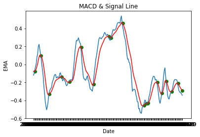

```python
fig, ax = plt.subplots()
plt.xlabel("Date")
plt.ylabel("EMA")
plt.title("MACD & Signal Line")
plt.plot(bac['Date'][29:],bac['macd'][29:])
plt.plot(bac['Date'][29:], bac['signal'][29:], color='red')
plt.scatter(BAC['Date'], BAC['signal'], marker='o', color='green')
plt.show()
```

2b) First, I read in the BAC data again to a new dataframe, and made the same adjustments as part a.

```python
bac2 = pd.DataFrame()
for i in range(0, len(sp500['Ticker'])):
    if sp500['Ticker'][i] == 'BAC':
        bac2 = bac2.append(sp500.iloc[i])

bac2 = bac2.reindex(sp500.columns, axis=1)
bac2 = bac2.reset_index(drop=True)
bac2.head()
```

|  | Date | Ticker | Open | High | Low | Close | Volume |
| --- | --- | --- | --- | --- | --- | --- | --- |
| 0 | 2009-08-21 | BAC | 17.46 | 17.60 | 17.31 | 17.46 | 2365971.0 |
| 1 | 2009-08-24 | BAC | 17.81 | 18.20 | 17.33 | 17.35 | 3166397.0 |
| 2 | 2009-08-25 | BAC | 17.56 | 18.00 | 17.55 | 17.75 | 2388167.0 |
| 3 | 2009-08-26 | BAC | 17.76 | 17.94 | 17.54 | 17.79 | 2038459.0 |
| 4 | 2009-08-27 | BAC | 17.75 | 17.98 | 17.59 | 17.92 | 1765370.0 |

Next, I used the equations/algorithm defined on Canvas to create the RSI strategy. This includes finding where the price went up or down, and counting the number of up ticks and number of down ticks on a rolling sum basis. Next, I was able to calculate the RS ratio, and in turn, calculate the RSI. From there, I was able to determine the buy and sell signals using the overbought and oversold thresholds specified.

```python
N=14
ob = 80
os = 20

bac2['u'] = np.where(bac2['Close'] > bac2['Close'].shift(1), 1, 0)
bac2['d'] = np.where(bac2['Close'] < bac2['Close'].shift(1), 1, 0)
bac2['nup'] = bac2['u'].rolling(N).sum()
bac2['ndown'] = bac2['d'].rolling(N).sum()
bac2['n_up'] = bac2['nup'].ewm(span=N, min_periods=N).mean()
bac2['n_down'] = bac2['ndown'].ewm(span=N, min_periods=N).mean()
bac2['rs'] = bac2['n_up'] / bac2['n_down']
bac2['rsi'] = 100 * bac2['rs'] / (1 + bac2['rs'])
bac2['bs_signals'] = np.where((bac2['rsi'].shift(1) > os) & (bac2['rsi'] <= os), 1, np.where((bac2['rsi'].shift(1) < ob) & (bac2['rsi'] >= ob), -1, 0))

bac2.tail()
```

|  | Date | Ticker | Open | High | Low | Close | Volume | u | d | nup | ndown | n_up | n_down | rs | rsi | bs_signals |
| --- | --- | --- | --- | --- | --- | --- | --- | --- | --- | --- | --- | --- | --- | --- | --- | --- |
| 240 | 2010-08-13 | BAC | 13.110 | 13.34 | 13.11 | 13.23 | 1079237.0 | 1 | 0 | 5.0 | 9.0 | 6.762676 | 6.977728 | 0.969180 | 49.217446 | 0 |
| 241 | 2010-08-16 | BAC | 13.130 | 13.29 | 13.09 | 13.19 | 997992.0 | 0 | 1 | 4.0 | 10.0 | 6.394319 | 7.380697 | 0.866357 | 46.419682 | 0 |
| 242 | 2010-08-17 | BAC | 13.405 | 13.45 | 13.15 | 13.21 | 1320475.0 | 1 | 0 | 5.0 | 9.0 | 6.208410 | 7.596604 | 0.817261 | 44.972135 | 0 |
| 243 | 2010-08-19 | BAC | 13.280 | 13.37 | 13.01 | 13.02 | 1533447.0 | 0 | 1 | 4.0 | 10.0 | 5.913955 | 7.917057 | 0.746989 | 42.758657 | 0 |
| 244 | 2010-08-20 | BAC | 12.980 | 12.99 | 12.75 | 12.87 | 1645067.0 | 0 | 1 | 3.0 | 11.0 | 5.525428 | 8.328116 | 0.663467 | 39.884579 | 0 |

Keeping it uniform throughout the code, I used the same method of calculating return as earlier. As you can see, RSI was able to generate a nice return.

```python
BAC2 = bac2[bac2['bs_signals'] != 0]
BAC2 = BAC2.append(bac2.iloc[-1])
BAC2['ret'] = np.log(BAC2.Close.shift(-1)) - np.log(BAC2.Close)
bac2_pnl = ((BAC2['bs_signals'] * BAC2['ret']) + 1).prod()
print('Accumulative Return: ' + str(100*(bac2_pnl-1)) + "%")
```

```
Accumulative Return: 41.03740444612471%
```

The following is a table of all the buy and sell signals, the date of trade and return.

```python
print(BAC2[['Date', 'bs_signals', 'ret']])
```

```
           Date  bs_signals       ret
155  2010-04-14          -1 -0.410374
244  2010-08-20           0       NaN
```

Finally, I plotted the RSI with the overbought and oversold lines. Whenever the RSI exceeds the red line, the algorithm will sell. Whenever the RSI falls below the green line, the algorithm will buy. The black dots represent where a trade was made.

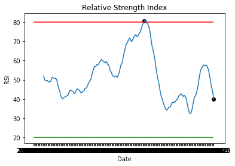

```python
fig, ax = plt.subplots()
plt.xlabel("Date")
plt.ylabel("RSI")
plt.title("Relative Strength Index")
plt.plot(bac2['Date'][13:], bac2['rsi'][13:])
plt.hlines(ob, bac2['Date'][13], bac2['Date'].iloc[-1], color='red')
plt.hlines(os, bac2['Date'][13], bac2['Date'].iloc[-1], color='green')
plt.scatter(BAC2['Date'], BAC2['rsi'], marker='o', color='black')
plt.show()
```

# Problem 3

First, I read in the data for the stocks XOM and CVX

```python
xom = pd.read_csv('XOM.csv')
cvx = pd.read_csv('CVX.csv')

xom.head()
```

|  | Date | Open | High | Low | Close | Adj Close | Volume |
| --- | --- | --- | --- | --- | --- | --- | --- |
| 0 | 2015-11-30 | 81.419998 | 82.650002 | 81.250000 | 81.660004 | 75.981720 | 17729200 |
| 1 | 2015-12-01 | 81.760002 | 82.129997 | 81.269997 | 81.889999 | 76.195717 | 13917000 |
| 2 | 2015-12-02 | 81.309998 | 81.639999 | 79.419998 | 79.550003 | 74.018433 | 16300000 |
| 3 | 2015-12-03 | 79.720001 | 79.849998 | 78.019997 | 78.410004 | 72.957710 | 14870300 |
| 4 | 2015-12-04 | 77.349998 | 78.980003 | 77.029999 | 78.860001 | 73.376411 | 20156400 |

3a) Next, I generated the log returns of XOM and CVX

```python
x = np.log(xom.Close) - np.log(xom.Close.shift(1))
y = np.log(cvx.Close) - np.log(cvx.Close.shift(1))
x = x.dropna()
y = y.dropna()
```

From there, I ran a linear regression on the returns to estimate the co-integrating relation.

```python
mod = sm.OLS(y, x).fit()
print(mod.summary())
```

```
                            OLS Regression Results
==============================================================================
Dep. Variable:                  Close   R-squared:                       0.528
Model:                            OLS   Adj. R-squared:                  0.527
Method:                 Least Squares   F-statistic:                     560.9
Date:                Mon, 29 Apr 2019   Prob (F-statistic):           9.30e-84
Time:                        20:44:34   Log-Likelihood:                 1657.2
No. Observations:                 502   AIC:                            -3312.
Df Residuals:                     501   BIC:                            -3308.
Df Model:                           1
Covariance Type:            nonrobust
==============================================================================
                 coef    std err          t      P>|t|      [0.025      0.975]
------------------------------------------------------------------------------
Close          0.8882      0.038     23.683      0.000       0.815       0.962
==============================================================================
Omnibus:                      100.814   Durbin-Watson:                   2.123
Prob(Omnibus):                  0.000   Jarque-Bera (JB):             1203.611
Skew:                           0.462   Prob(JB):                    4.36e-262
Kurtosis:                      10.529   Cond. No.                         1.00
==============================================================================

Warnings:
[1] Standard Errors assume that the covariance matrix of the errors is correctly specified.
```

As you can see below, here I calculate and plot of the residual. We will need this for the next part.

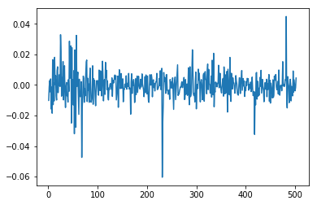

```python
residual = (mod.predict(x) - y)
plt.plot(residual)
plt.show()
```

3b) Next, I tested for stationarity of the residual with an Augmented Dickey Fuller unit root test using the package specified

```python
statsmodels.tsa.stattools.adfuller(residual)
```

```
(-23.88390666288238,
 0.0,
 0,
 501,
 {'1%': -3.443470002903981,
  '5%': -2.867326248740681,
  '10%': -2.569851849873108},
 -3194.156330044102)
```

3c) The next part I did was calculate delta using the formula given, which enabled me to calculate the buy and sell signals using the OLS coefficient, log returns of our stocks, and delta as the threshold.

```python
delta = 2 * np.std(residual)
signal = np.where(np.abs(y - 0.8882 * x) > delta, np.where((y - 0.8882 * x ) > delta, 1, -1), 0)
```

Here, I appended those buy and sell signals to the xom and cvx dataframes, which will be needed for future calculation

```python
xom['signal'] = 0 * xom['Close']
cvx['signal'] = 0 * cvx['Close']

for i in range(0, len(xom['Close'])):
    xom['signal'][i] = signal[i-1]
    cvx['signal'][i] = -signal[i-1]
```

Next, I created a new dataframe for xom and cvx, which I filtered only the entries where a trade is made using the signal

```python
XOM = xom[xom['signal'] != 0]
XOM = XOM.append(xom.iloc[-1])

CVX = cvx[cvx['signal'] != 0]
CVX = CVX.append(cvx.iloc[-1])

XOM
```

|  | Date | Open | High | Low | Close | Adj Close | Volume | signal |
| --- | --- | --- | --- | --- | --- | --- | --- | --- |
| 8 | 2015-12-10 | 75.800003 | 77.500000 | 75.519997 | 75.690002 | 70.426834 | 20076900 | 1.0 |
| 13 | 2015-12-17 | 79.019997 | 79.230003 | 77.949997 | 77.959999 | 72.538986 | 17362900 | -1.0 |
| 25 | 2016-01-06 | 76.639999 | 77.639999 | 76.589996 | 77.470001 | 72.083069 | 18826900 | -1.0 |
| 26 | 2016-01-07 | 76.059998 | 77.989998 | 75.900002 | 76.230003 | 70.929298 | 21263800 | -1.0 |
| 43 | 2016-02-02 | 74.190002 | 75.620003 | 73.550003 | 74.589996 | 69.403320 | 21404200 | -1.0 |
| 46 | 2016-02-05 | 79.400002 | 80.099998 | 78.570000 | 80.080002 | 74.511581 | 26719900 | -1.0 |
| 47 | 2016-02-08 | 79.300003 | 81.779999 | 78.910004 | 81.160004 | 75.516472 | 26601200 | 1.0 |
| 48 | 2016-02-09 | 79.980003 | 80.669998 | 78.690002 | 80.080002 | 75.187866 | 18112900 | -1.0 |
| 53 | 2016-02-17 | 81.650002 | 82.779999 | 81.160004 | 82.000000 | 76.990562 | 17006700 | 1.0 |
| 54 | 2016-02-18 | 82.900002 | 83.059998 | 81.860001 | 82.449997 | 77.413055 | 14873700 | -1.0 |
| 56 | 2016-02-22 | 82.500000 | 83.440002 | 82.199997 | 82.389999 | 77.356743 | 14595200 | 1.0 |
| 57 | 2016-02-23 | 81.989998 | 82.370003 | 80.879997 | 81.230003 | 76.267601 | 11041600 | -1.0 |
| 62 | 2016-03-01 | 80.559998 | 81.769997 | 80.320000 | 81.279999 | 76.314545 | 15730600 | 1.0 |
| 68 | 2016-03-09 | 83.220001 | 83.849998 | 82.239998 | 82.400002 | 77.366135 | 14139300 | 1.0 |
| 167 | 2016-07-29 | 87.610001 | 89.010002 | 86.120003 | 88.949997 | 84.217880 | 23928100 | 1.0 |
| 231 | 2016-10-28 | 85.279999 | 86.360001 | 84.139999 | 84.779999 | 80.954231 | 19072200 | 1.0 |
| 232 | 2016-10-31 | 83.879997 | 84.400002 | 82.989998 | 83.320000 | 79.560104 | 16663800 | 1.0 |
| 292 | 2017-01-27 | 85.300003 | 85.750000 | 85.040001 | 85.510002 | 82.374298 | 10947900 | -1.0 |
| 335 | 2017-03-30 | 82.029999 | 83.870003 | 81.940002 | 83.699997 | 81.367958 | 44704900 | -1.0 |
| 368 | 2017-05-17 | 82.550003 | 83.040001 | 81.959999 | 81.989998 | 80.458282 | 11151100 | -1.0 |
| 418 | 2017-07-28 | 79.650002 | 79.919998 | 78.269997 | 79.599998 | 78.112930 | 22800800 | 1.0 |
| 482 | 2017-10-27 | 83.000000 | 84.239998 | 82.010002 | 83.709999 | 82.942383 | 14866200 | -1.0 |
| 502 | 2017-11-27 | 81.320000 | 81.400002 | 81.019997 | 81.110001 | 81.110001 | 8693600 | 0.0 |

Next, I calculate the returns from each of those trades

```python
XOM['ret'] = np.log(XOM.Close.shift(-1)) - np.log(XOM.Close)
CVX['ret'] = np.log(CVX.Close.shift(-1)) - np.log(CVX.Close)
```

This is a table of XOM's long short shignals as well as returns for each trade

```python
XOM
```

|  | Date | Open | High | Low | Close | Adj Close | Volume | signal | ret |
| --- | --- | --- | --- | --- | --- | --- | --- | --- | --- |
| 8 | 2015-12-10 | 75.800003 | 77.500000 | 75.519997 | 75.690002 | 70.426834 | 20076900 | 1.0 | 0.029550 |
| 13 | 2015-12-17 | 79.019997 | 79.230003 | 77.949997 | 77.959999 | 72.538986 | 17362900 | -1.0 | -0.006305 |
| 25 | 2016-01-06 | 76.639999 | 77.639999 | 76.589996 | 77.470001 | 72.083069 | 18826900 | -1.0 | -0.016136 |
| 26 | 2016-01-07 | 76.059998 | 77.989998 | 75.900002 | 76.230003 | 70.929298 | 21263800 | -1.0 | -0.021749 |
| 43 | 2016-02-02 | 74.190002 | 75.620003 | 73.550003 | 74.589996 | 69.403320 | 21404200 | -1.0 | 0.071020 |
| 46 | 2016-02-05 | 79.400002 | 80.099998 | 78.570000 | 80.080002 | 74.511581 | 26719900 | -1.0 | 0.013396 |
| 47 | 2016-02-08 | 79.300003 | 81.779999 | 78.910004 | 81.160004 | 75.516472 | 26601200 | 1.0 | -0.013396 |
| 48 | 2016-02-09 | 79.980003 | 80.669998 | 78.690002 | 80.080002 | 75.187866 | 18112900 | -1.0 | 0.023693 |
| 53 | 2016-02-17 | 81.650002 | 82.779999 | 81.160004 | 82.000000 | 76.990562 | 17006700 | 1.0 | 0.005473 |
| 54 | 2016-02-18 | 82.900002 | 83.059998 | 81.860001 | 82.449997 | 77.413055 | 14873700 | -1.0 | -0.000728 |
| 56 | 2016-02-22 | 82.500000 | 83.440002 | 82.199997 | 82.389999 | 77.356743 | 14595200 | 1.0 | -0.014179 |
| 57 | 2016-02-23 | 81.989998 | 82.370003 | 80.879997 | 81.230003 | 76.267601 | 11041600 | -1.0 | 0.000615 |
| 62 | 2016-03-01 | 80.559998 | 81.769997 | 80.320000 | 81.279999 | 76.314545 | 15730600 | 1.0 | 0.013685 |
| 68 | 2016-03-09 | 83.220001 | 83.849998 | 82.239998 | 82.400002 | 77.366135 | 14139300 | 1.0 | 0.076489 |
| 167 | 2016-07-29 | 87.610001 | 89.010002 | 86.120003 | 88.949997 | 84.217880 | 23928100 | 1.0 | -0.048015 |
| 231 | 2016-10-28 | 85.279999 | 86.360001 | 84.139999 | 84.779999 | 80.954231 | 19072200 | 1.0 | -0.017371 |
| 232 | 2016-10-31 | 83.879997 | 84.400002 | 82.989998 | 83.320000 | 79.560104 | 16663800 | 1.0 | 0.025945 |
| 292 | 2017-01-27 | 85.300003 | 85.750000 | 85.040001 | 85.510002 | 82.374298 | 10947900 | -1.0 | -0.021394 |
| 335 | 2017-03-30 | 82.029999 | 83.870003 | 81.940002 | 83.699997 | 81.367958 | 44704900 | -1.0 | -0.020642 |
| 368 | 2017-05-17 | 82.550003 | 83.040001 | 81.959999 | 81.989998 | 80.458282 | 11151100 | -1.0 | -0.029583 |
| 418 | 2017-07-28 | 79.650002 | 79.919998 | 78.269997 | 79.599998 | 78.112930 | 22800800 | 1.0 | 0.050344 |
| 482 | 2017-10-27 | 83.000000 | 84.239998 | 82.010002 | 83.709999 | 82.942383 | 14866200 | -1.0 | -0.031552 |
| 502 | 2017-11-27 | 81.320000 | 81.400002 | 81.019997 | 81.110001 | 81.110001 | 8693600 | 0.0 | NaN |

This is a table of CVX's long short shignals as well as returns for each trade

```python
CVX
```

|  | Date | Open | High | Low | Close | Adj Close | Volume | signal | ret |
| --- | --- | --- | --- | --- | --- | --- | --- | --- | --- |
| 8 | 2015-12-10 | 88.000000 | 90.459999 | 87.610001 | 89.300003 | 82.226425 | 14503300 | -1.0 | 0.013790 |
| 13 | 2015-12-17 | 93.500000 | 94.000000 | 90.400002 | 90.540001 | 83.368210 | 14082500 | 1.0 | -0.050631 |
| 25 | 2016-01-06 | 87.440002 | 87.779999 | 85.160004 | 86.070000 | 79.252281 | 14511400 | 1.0 | -0.036079 |
| 26 | 2016-01-07 | 84.550003 | 85.750000 | 82.669998 | 83.019997 | 76.443871 | 15368800 | 1.0 | -0.021674 |
| 43 | 2016-02-02 | 82.709999 | 83.040001 | 80.959999 | 81.239998 | 74.804871 | 13326200 | 1.0 | 0.019986 |
| 46 | 2016-02-05 | 83.940002 | 84.290001 | 82.260002 | 82.879997 | 76.314964 | 15090100 | 1.0 | 0.036837 |
| 47 | 2016-02-08 | 81.760002 | 86.699997 | 81.099998 | 85.989998 | 79.178619 | 17712800 | -1.0 | -0.036355 |
| 48 | 2016-02-09 | 85.080002 | 85.790001 | 82.169998 | 82.919998 | 76.351784 | 12377800 | 1.0 | 0.062977 |
| 53 | 2016-02-17 | 85.410004 | 88.660004 | 85.019997 | 88.309998 | 82.346222 | 12710500 | -1.0 | -0.018053 |
| 54 | 2016-02-18 | 88.750000 | 89.250000 | 86.610001 | 86.730003 | 80.872932 | 9517800 | 1.0 | 0.023812 |
| 56 | 2016-02-22 | 86.500000 | 89.839996 | 86.500000 | 88.820000 | 82.821793 | 10299900 | -1.0 | -0.045020 |
| 57 | 2016-02-23 | 88.389999 | 88.480003 | 84.699997 | 84.910004 | 79.175819 | 10655800 | 1.0 | 0.014266 |
| 62 | 2016-03-01 | 84.120003 | 86.529999 | 83.370003 | 86.129997 | 80.313446 | 11614700 | -1.0 | 0.074804 |
| 68 | 2016-03-09 | 89.699997 | 94.639999 | 89.470001 | 92.820000 | 86.551643 | 19323100 | -1.0 | 0.099006 |
| 167 | 2016-07-29 | 100.529999 | 102.660004 | 99.849998 | 102.480003 | 96.569450 | 10157600 | -1.0 | 0.012991 |
| 231 | 2016-10-28 | 101.120003 | 105.029999 | 100.949997 | 103.820000 | 98.862991 | 17435400 | -1.0 | 0.008918 |
| 232 | 2016-10-31 | 103.820000 | 105.459999 | 103.779999 | 104.750000 | 99.748596 | 12340800 | -1.0 | 0.082778 |
| 292 | 2017-01-27 | 113.529999 | 114.699997 | 112.849998 | 113.790001 | 109.441742 | 11698900 | 1.0 | -0.054263 |
| 335 | 2017-03-30 | 108.150002 | 108.680000 | 107.199997 | 107.779999 | 104.653641 | 6797700 | 1.0 | -0.028993 |
| 368 | 2017-05-17 | 106.169998 | 106.269997 | 104.620003 | 104.699997 | 102.697128 | 6384300 | 1.0 | 0.032143 |
| 418 | 2017-07-28 | 106.709999 | 109.129997 | 106.360001 | 108.120003 | 106.051712 | 7812600 | -1.0 | 0.048913 |
| 482 | 2017-10-27 | 116.129997 | 116.400002 | 112.570000 | 113.540001 | 112.486992 | 14534100 | 1.0 | 0.017894 |
| 502 | 2017-11-27 | 115.849998 | 116.029999 | 115.239998 | 115.589996 | 115.589996 | 4290500 | 0.0 | NaN |

Finally, I calculate the individual accumulative returns for XOM and CVX, and then combine them to get the overall accumulative return

```python
retX = ((XOM['signal'] * XOM['ret']) + 1).prod()
print('retX: ' + str(retX-1))

retY = ((CVX['signal'] * CVX['ret']) + 1).prod()
print('retY: ' + str(retY-1))
```

```
retX: 0.14650421094809363
retY: -0.2200803569122729
```

```python
total_ret = retX * retY
print("Accumulative Return: " + str(100*(total_ret-1)) + "%")
```

```
Accumulative Return: -10.581884499878669%
```